# Projet simulation de file d’attente

## Perte de paquets

Le pourcentage de paquets perdus théorique est donné par cette formule :
$$P(X_t=N)=\frac{1-\rho}{1-\rho^{N+1}}\rho^N$$

Pour trouver une valeur empirique à cette probabilité nous pouvons tracer le pourcentage de paquets perdus sur le total de paquets arrivés pour différentes valeurs de $\lambda$.

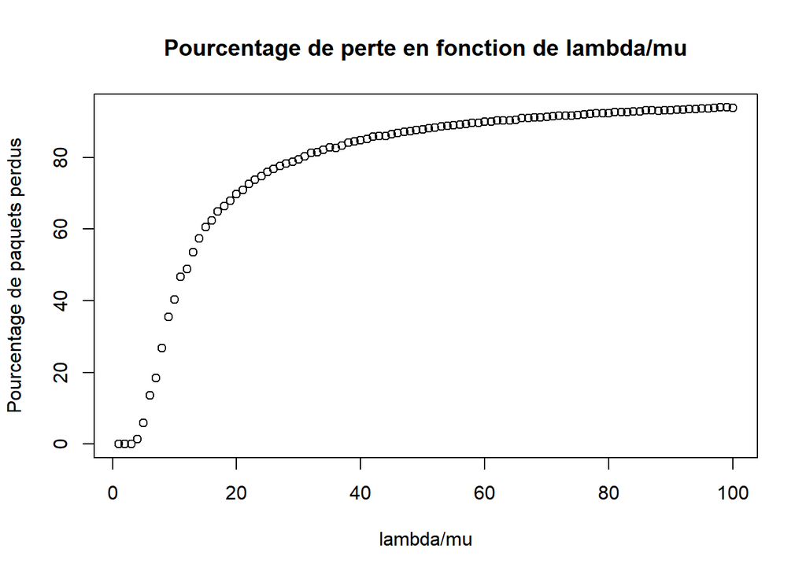

Le taux de perte est donc élevé puisqu’il monte au delà de 40% pour un ratio $\lambda/\mu$=10. Il est intéressant de noter que ce taux augmente de manière quasi logarithmique

Afin de résoudre ce problème on peut soit augmenter la taille du buffer d’attente ou encore ajouter des serveurs. C’est ce que nous allons voir.

## Effets de l’augmentation du nombre de serveurs

Pour simuler une augmentation du nombre de serveur, nous avons choisis d’opter pour une boucle au sein de notre partie traitement de requêtes Ainsi, à chaque fois qu’une période de traitement arrive, on ne traite pas 1 mais N requêtes. Par convention, nous avons également choisi de multiplier la taille de la file passé en paramètre par N. Une autre méthode qui aurait pu être mis en place aurait été de multiplier le paramètre $\mu$ par N pour diviser le temps avant le prochain traitement. Sur le graphe ci-dessous, vous pouvez voir les effets de l’augmentation du nombre de serveurs.

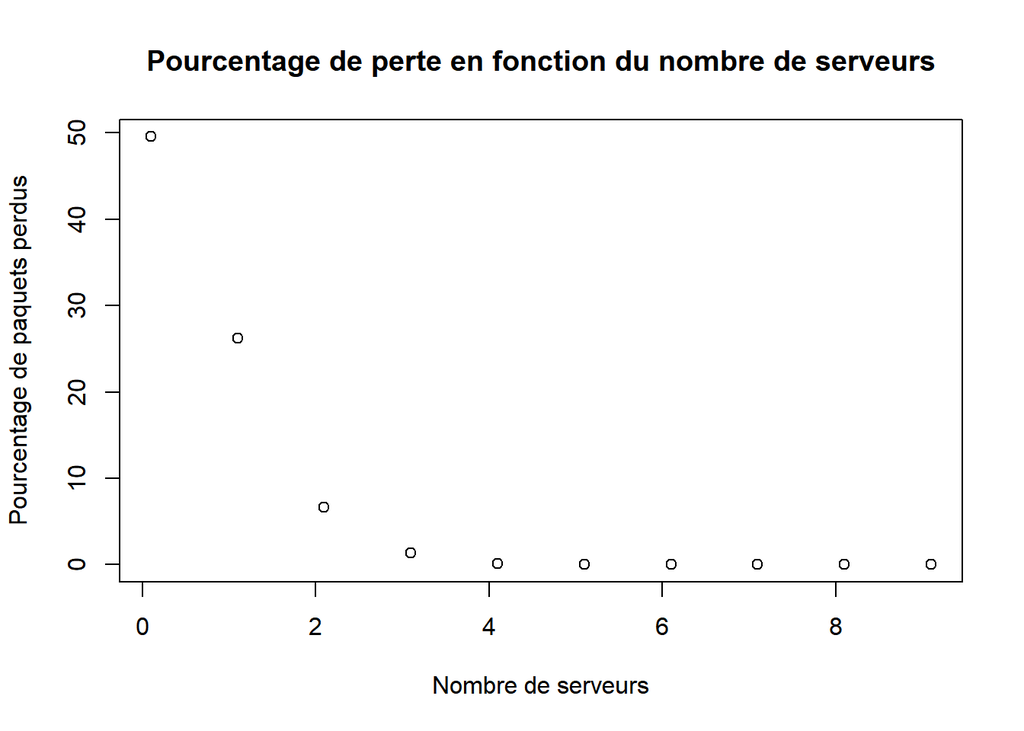

Pour une queue de 10 éléments et un ratio $\lambda/\mu$=12, il suffit de 4 serveurs pour arriver à un nombre nul ou quasi nul de paquets perdus.